# LoanAnalysis_Decision_Tree

```python
#Importing all the neccesary Libraries for the analysis

import numpy as np

import pandas as pd

import seaborn as sns

import matplotlib.pyplot as plt
```

```python
#Loading the Dataset from the local system

df = pd.read_csv(r"C:\Users\visha\Downloads\Loan Delinquent Dataset (1).csv")
```

```python
#Printing the Dataset

df
```

|  | ID | delinquent | Sdelinquent | term | gender | purpose | home_ownership | age | FICO |
| --- | --- | --- | --- | --- | --- | --- | --- | --- | --- |
| 0 | 1 | Yes | 1 | 36 months | Female | House | Mortgage | >25 | 300-500 |
| 1 | 2 | No | 0 | 36 months | Female | House | Rent | 20-25 | >500 |
| 2 | 3 | Yes | 1 | 36 months | Female | House | Rent | >25 | 300-500 |
| 3 | 4 | Yes | 1 | 36 months | Female | Car | Mortgage | >25 | 300-500 |
| 4 | 5 | Yes | 1 | 36 months | Female | House | Rent | >25 | 300-500 |
| ... | ... | ... | ... | ... | ... | ... | ... | ... | ... |
| 11543 | 11544 | No | 0 | 60 months | Male | other | Mortgage | >25 | 300-500 |
| 11544 | 11545 | Yes | 1 | 36 months | Male | House | Rent | 20-25 | 300-500 |
| 11545 | 11546 | No | 0 | 36 months | Female | Personal | Mortgage | 20-25 | >500 |
| 11546 | 11547 | Yes | 1 | 36 months | Female | House | Rent | 20-25 | 300-500 |
| 11547 | 11548 | Yes | 1 | 36 months | Male | Personal | Mortgage | 20-25 | 300-500 |

11548 rows × 9 columns

### -------------------------------------EDA Operations----------------------------------------------------------------

```python
#Printing first 5 rows

df.head()
```

|  | ID | delinquent | Sdelinquent | term | gender | purpose | home_ownership | age | FICO |
| --- | --- | --- | --- | --- | --- | --- | --- | --- | --- |
| 0 | 1 | Yes | 1 | 36 months | Female | House | Mortgage | >25 | 300-500 |
| 1 | 2 | No | 0 | 36 months | Female | House | Rent | 20-25 | >500 |
| 2 | 3 | Yes | 1 | 36 months | Female | House | Rent | >25 | 300-500 |
| 3 | 4 | Yes | 1 | 36 months | Female | Car | Mortgage | >25 | 300-500 |
| 4 | 5 | Yes | 1 | 36 months | Female | House | Rent | >25 | 300-500 |

```python
#Printing last 5 rows

df.tail()
```

|  | ID | delinquent | Sdelinquent | term | gender | purpose | home_ownership | age | FICO |
| --- | --- | --- | --- | --- | --- | --- | --- | --- | --- |
| 11543 | 11544 | No | 0 | 60 months | Male | other | Mortgage | >25 | 300-500 |
| 11544 | 11545 | Yes | 1 | 36 months | Male | House | Rent | 20-25 | 300-500 |
| 11545 | 11546 | No | 0 | 36 months | Female | Personal | Mortgage | 20-25 | >500 |
| 11546 | 11547 | Yes | 1 | 36 months | Female | House | Rent | 20-25 | 300-500 |
| 11547 | 11548 | Yes | 1 | 36 months | Male | Personal | Mortgage | 20-25 | 300-500 |

```python
#To print the total no of rows and columns of the dataset

df.shape

# (m x n)
```

```
(11548, 9)
```

```python
#To print the columns in the dataset

df.columns
```

```
Index(['ID', 'delinquent', 'Sdelinquent', 'term', 'gender', 'purpose',
       'home_ownership', 'age', 'FICO'],
      dtype='object')
```

```python
#To know about the datatypes of the dataset

df.dtypes

#The dataset has 2 integer columns and others as object.
```

```
ID                 int64
delinquent        object
Sdelinquent        int64
term              object
gender            object
purpose           object
home_ownership    object
age               object
FICO              object
dtype: object
```

```python
#To Describe in detail about the dataset about the

df.describe()
```

|  | ID | Sdelinquent |
| --- | --- | --- |
| count | 11548.000000 | 11548.000000 |
| mean | 5774.500000 | 0.668601 |
| std | 3333.764789 | 0.470737 |
| min | 1.000000 | 0.000000 |
| 25% | 2887.750000 | 0.000000 |
| 50% | 5774.500000 | 1.000000 |
| 75% | 8661.250000 | 1.000000 |
| max | 11548.000000 | 1.000000 |

```python
#To describe in detail along with including the object variable also

df.describe(include="all")

# THE TOP MOST VALUES FOLLOWED IN THE DATASET IS:

#top	NaN	Yes	NaN	36 months	Male	House	Mortgage	20-25	300-500
```

|  | ID | delinquent | Sdelinquent | term | gender | purpose | home_ownership | age | FICO |
| --- | --- | --- | --- | --- | --- | --- | --- | --- | --- |
| count | 11548.000000 | 11548 | 11548.000000 | 11548 | 11548 | 11548 | 11548 | 11548 | 11548 |
| unique | NaN | 2 | NaN | 2 | 2 | 7 | 3 | 2 | 2 |
| top | NaN | Yes | NaN | 36 months | Male | House | Mortgage | 20-25 | 300-500 |
| freq | NaN | 7721 | NaN | 10589 | 6555 | 6892 | 5461 | 5888 | 6370 |
| mean | 5774.500000 | NaN | 0.668601 | NaN | NaN | NaN | NaN | NaN | NaN |
| std | 3333.764789 | NaN | 0.470737 | NaN | NaN | NaN | NaN | NaN | NaN |
| min | 1.000000 | NaN | 0.000000 | NaN | NaN | NaN | NaN | NaN | NaN |
| 25% | 2887.750000 | NaN | 0.000000 | NaN | NaN | NaN | NaN | NaN | NaN |
| 50% | 5774.500000 | NaN | 1.000000 | NaN | NaN | NaN | NaN | NaN | NaN |
| 75% | 8661.250000 | NaN | 1.000000 | NaN | NaN | NaN | NaN | NaN | NaN |
| max | 11548.000000 | NaN | 1.000000 | NaN | NaN | NaN | NaN | NaN | NaN |

```python
#To check for null values in the dataset

df.isnull()
```

|  | ID | delinquent | Sdelinquent | term | gender | purpose | home_ownership | age | FICO |
| --- | --- | --- | --- | --- | --- | --- | --- | --- | --- |
| 0 | False | False | False | False | False | False | False | False | False |
| 1 | False | False | False | False | False | False | False | False | False |
| 2 | False | False | False | False | False | False | False | False | False |
| 3 | False | False | False | False | False | False | False | False | False |
| 4 | False | False | False | False | False | False | False | False | False |
| ... | ... | ... | ... | ... | ... | ... | ... | ... | ... |
| 11543 | False | False | False | False | False | False | False | False | False |
| 11544 | False | False | False | False | False | False | False | False | False |
| 11545 | False | False | False | False | False | False | False | False | False |
| 11546 | False | False | False | False | False | False | False | False | False |
| 11547 | False | False | False | False | False | False | False | False | False |

11548 rows × 9 columns

```python
#To check for null values in the dataset

df.isnull().sum()
```

```
ID                0
delinquent        0
Sdelinquent       0
term              0
gender            0
purpose           0
home_ownership    0
age               0
FICO              0
dtype: int64
```

```python
#To check for null values in the dataset

df.isnull().count()
```

```
ID                11548
delinquent        11548
Sdelinquent       11548
term              11548
gender            11548
purpose           11548
home_ownership    11548
age               11548
FICO              11548
dtype: int64
```

```python
# The dataset doesn't has any NULL values in the dataset .
```

```python
#To know about the duplicates in the dataset

df.duplicated()
```

```
0        False
1        False
2        False
3        False
4        False
         ...
11543    False
11544    False
11545    False
11546    False
11547    False
Length: 11548, dtype: bool
```

```python
#To know about the duplicates in the dataset

df.duplicated().sum()
```

```
0
```

```python
#To know about the duplicates in the dataset

df.duplicated().count()
```

```
11548
```

```python
# The dataset doesn't has any Duplicate values in the dataset .
```

```python
#   UNIVARIATE ANALYSIS
```

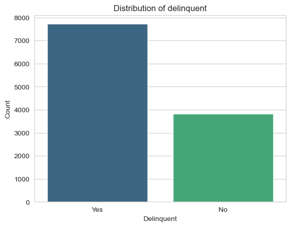

```python
sns.set_style("whitegrid")

sns.countplot(x=df['delinquent'],palette = "viridis")
plt.title(f"Distribution of delinquent")
plt.xlabel("Delinquent")
plt.ylabel("Count")
plt.show()
```

#### So , Overall the chart displays that the count of Delinquent vs the Deliquent which clearly states that the people who are deliquent id apprxoimately twice than those are not deliquent.

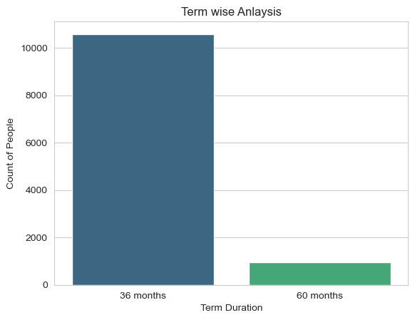

```python
sns.set_style("whitegrid")

sns.countplot(x=df['term'],palette = "viridis")
plt.title(f"Term wise Anlaysis")
plt.xlabel("Term Duration")
plt.ylabel("Count of People")
plt.show()
```

#### This graph displays the Avearge Time Duration that people have taken Loan from the graph it can be undertood that most of the people about 90% of the total population has taken or prefered Loan for 36 months

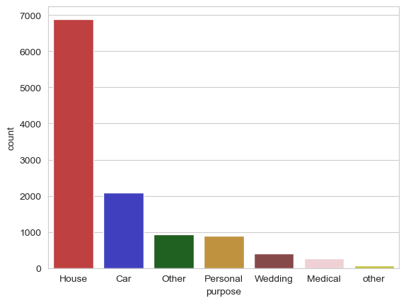

```python
u=["red","blue","green","orange","brown","pink","yellow"]

sns.countplot(data=df,x="purpose",palette=u,saturation=0.5)

plt.show()
```

#### The maximum people has bought loan for their Housing and followed by Car and others.

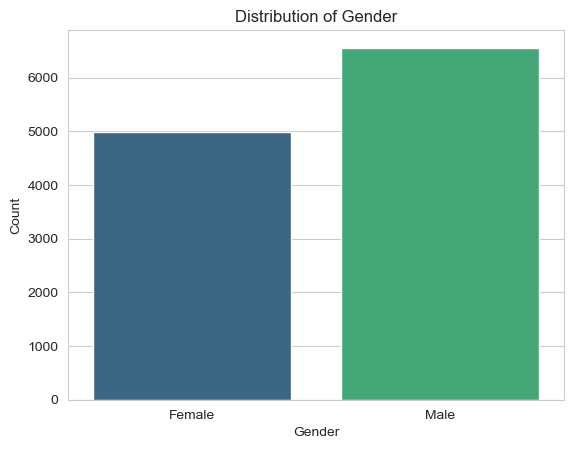

```python
sns.set_style("whitegrid")

sns.countplot(x=df['gender'],palette = "viridis")
plt.title(f"Distribution of Gender")
plt.xlabel("Gender")
plt.ylabel("Count")
plt.show()
```

#### Considering Gender from the above grapgh Male/Men are involved more in Loan Acttivites when compared to Female/Women.

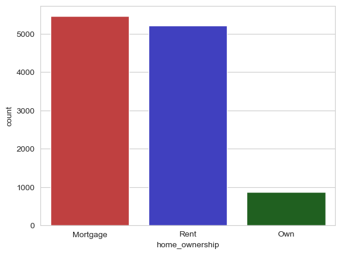

```python
u=["red","blue","green"]

sns.countplot(data=df,x="home_ownership",palette=u,saturation=0.5)

plt.show()
```

#### When dealing with the Ownership methods, Mortgage and Rent has contributed the most when compared to Own.

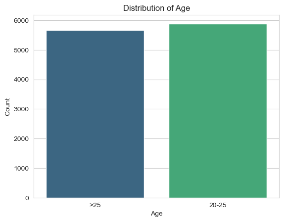

```python
sns.set_style("whitegrid")

sns.countplot(x=df['age'],palette = "viridis")
plt.title(f"Distribution of Age")
plt.xlabel("Age")
plt.ylabel("Count")
plt.show()
```